# Unit 3 Project

Ada Lazuli

April 12, 2026

## Front Matter

```r
remove(list = ls())
#Load libraries
library(reactable)
library(patchwork)
library(tidyverse)
library(pROC)
library(FNN)
library(rpart)
library(rattle)
#Read datasets into Environment
library(glmnet)
cod_df <- read.csv("../../sample_data/STAT508_CODGamesP2.csv")
```

## Task 1 EDA and Wrangling before Modeling

#### Data Wrangling

First, subset the data to only observations that are of a full game.

```r
cod_df <- cod_df %>%
  filter(FullPartial == "Full")


sum(cod_df$PlayerTeamScore == cod_df$OpponentTeamScore)
```

```
## [1] 3
```

It appears that there are exactly 3 instances of ties in the data.

The rule for deciding the outcome will be whichever side had the largest score. This should account for games running till the timer runs out and games where a team exceeds the victory scoring threshold. Additionally, since we only have 3 instances of a tie, we will discard those observations. Being able to predict a tie is not very useful for the research question and since there are only 3 examples, the models will likely perform poorly to predict it.

```r
cod_df <- cod_df %>%
  filter(!(PlayerTeamScore == OpponentTeamScore)) %>%
  mutate(Outcome = ifelse(PlayerTeamScore > OpponentTeamScore, 1, 0))
reactable(cod_df)
```

| Level | FullPartial | PlayerTeamScore | OpponentTeamScore | Eliminations | Deaths | Score | Damage | TotalXP | XPType | Mode | Game | Outcome |
| --- | --- | --- | --- | --- | --- | --- | --- | --- | --- | --- | --- | --- |
| Miami Strike | Full | 100 | 97 | 22 | 17 | 4070 | 634 | 11002 | Regular | HardCore | TDM | 1 |
| Moscow | Full | 76 | 89 | 20 | 15 | 5305 | 560 | 9451 | Regular | HardCore | TDM | 0 |
| Yamantau | Full | 100 | 92 | 18 | 11 | 3335 | 483 | 12948 | Regular | HardCore | TDM | 1 |
| Drive-In | Full | 80 | 100 | 10 | 19 | 2170 | 280 | 11502 | Double | HardCore | TDM | 0 |
| Collateral Strike | Full | 71 | 100 | 11 | 19 | 2195 | 308 | 11133 | Double | HardCore | TDM | 0 |
| Raid | Full | 85 | 100 | 7 | 18 | 850 | 196 | 10077 | Double | HardCore | TDM | 0 |
| WMD | Full | 86 | 100 | 10 | 21 | 2240 | 259 | 8527 | Regular | HardCore | TDM | 0 |
| Standoff | Full | 100 | 70 | 18 | 14 | 3505 | 504 | 16703 | Double | HardCore | TDM | 1 |
| Deprogram | Full | 46 | 65 | 11 | 23 | 1985 | 304 | 10404 | Regular | HardCore | Kill Confirmed | 0 |
| Nuketown '84 | Full | 47 | 65 | 23 | 12 | 3400 | 617 | 9516 | Regular | HardCore | Kill Confirmed | 0 |

[output cut: 479 more lines]

```r
table(cod_df$Outcome)
```

```
##
##   0   1
## 215 274
```

Now the outcome has been recorded with a “1” for a win and a “0” for a loss.

Next, the following features will be removed to tidy the data:

1. PlayerTeamScore - Since this was used derive the outcome
2. OpponentTeamScore - Since this was used to derive the outcome
3. FullPartial - Since this only contains “Full” after sub-setting

```r
cod_df <- cod_df %>% select(-FullPartial, -PlayerTeamScore, -OpponentTeamScore)
```

#### EDA on Constructed Outcomes

Since the outcome is a new feature, it is worthwhile to explore explore how the other features interact with the new outcomes feature.

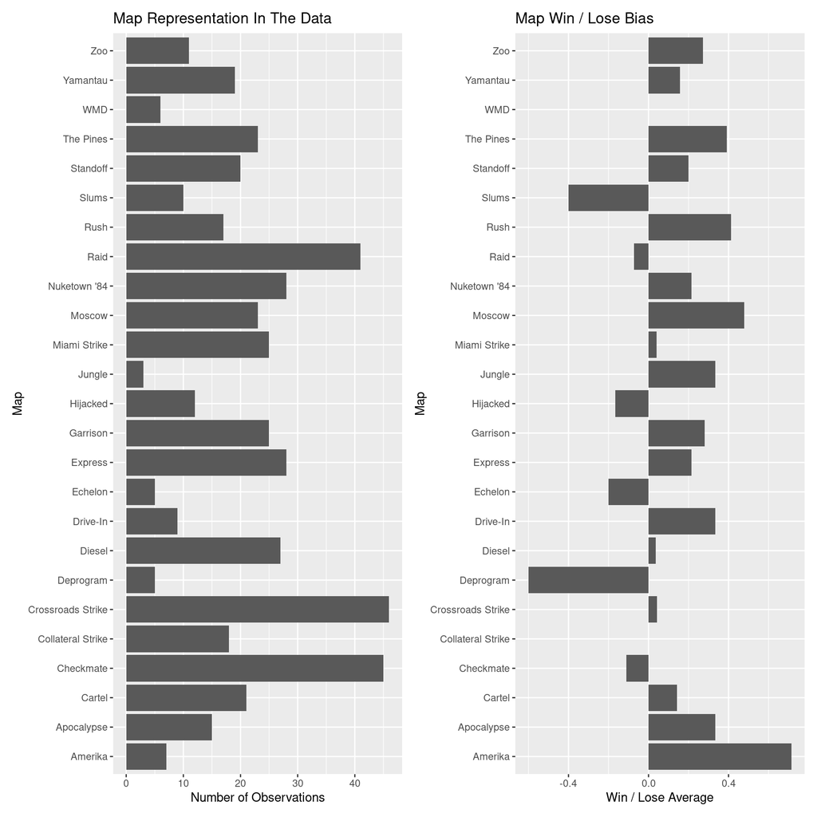

```r
temp_df <- cod_df %>%
  mutate(Outcome = ifelse(Outcome == 1, 1, -1)) %>%
  group_by(Level) %>%
  summarise(Outcome = mean(Outcome),
            Count = n())

frequency <- ggplot(temp_df, aes(x = Level, y = Count)) + geom_col() + coord_flip() + labs(x = "Map", y = "Number of Observations",
                                                                                                         title = "Map Representation In The Data")
outcome_bias <- ggplot(temp_df, aes(x = Level, y = Outcome)) + geom_col() + coord_flip() + labs(x = "Map", y = "Win / Lose Average",
                                                                                                         title = "Map Win / Lose Bias")
(frequency+outcome_bias)
```

Based on the level plots, it appears that some maps favor victory while others are biased towards a loss. Considering that the data might not be all inclusive of all of the maps, DLC might add more maps in the future, and the data does not capture which “side” a map favors, such as blue team or red team. It seems appropriate to drop the level feature from future consideration.

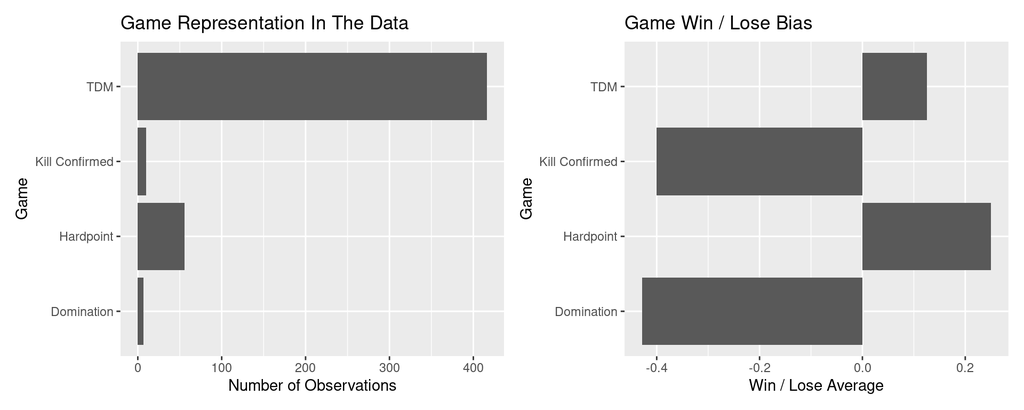

```r
cod_df <- cod_df %>% select(-Level)

temp_df <- cod_df %>%
  mutate(Outcome = ifelse(Outcome == 1, 1, -1)) %>%
  group_by(Game) %>%
  summarise(Outcome = mean(Outcome),
            Count = n())

frequency <- ggplot(temp_df, aes(x = Game, y = Count)) + geom_col() + coord_flip() + labs(x = "Game", y = "Number of Observations",
                                                                                                         title = "Game Representation In The Data")
outcome_bias <- ggplot(temp_df, aes(x = Game, y = Outcome)) + geom_col() + coord_flip() + labs(x = "Game", y = "Win / Lose Average",
                                                                                                         title = "Game Win / Lose Bias")
(frequency+outcome_bias)
```

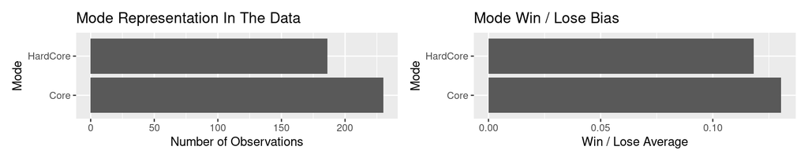

```r
cod_df <- cod_df %>% filter(Game == "TDM") %>% select(-Game)

temp_df <- cod_df %>%
  mutate(Outcome = ifelse(Outcome == 1, 1, -1)) %>%
  group_by(Mode) %>%
  summarise(Outcome = mean(Outcome),
            Count = n())

frequency <- ggplot(temp_df, aes(x = Mode, y = Count)) + geom_col() + coord_flip() + labs(x = "Mode", y = "Number of Observations",
                                                                                                         title = "Mode Representation In The Data")
outcome_bias <- ggplot(temp_df, aes(x = Mode, y = Outcome)) + geom_col() + coord_flip() + labs(x = "Mode", y = "Win / Lose Average",
                                                                                                         title = "Mode Win / Lose Bias")
(frequency+outcome_bias)
```

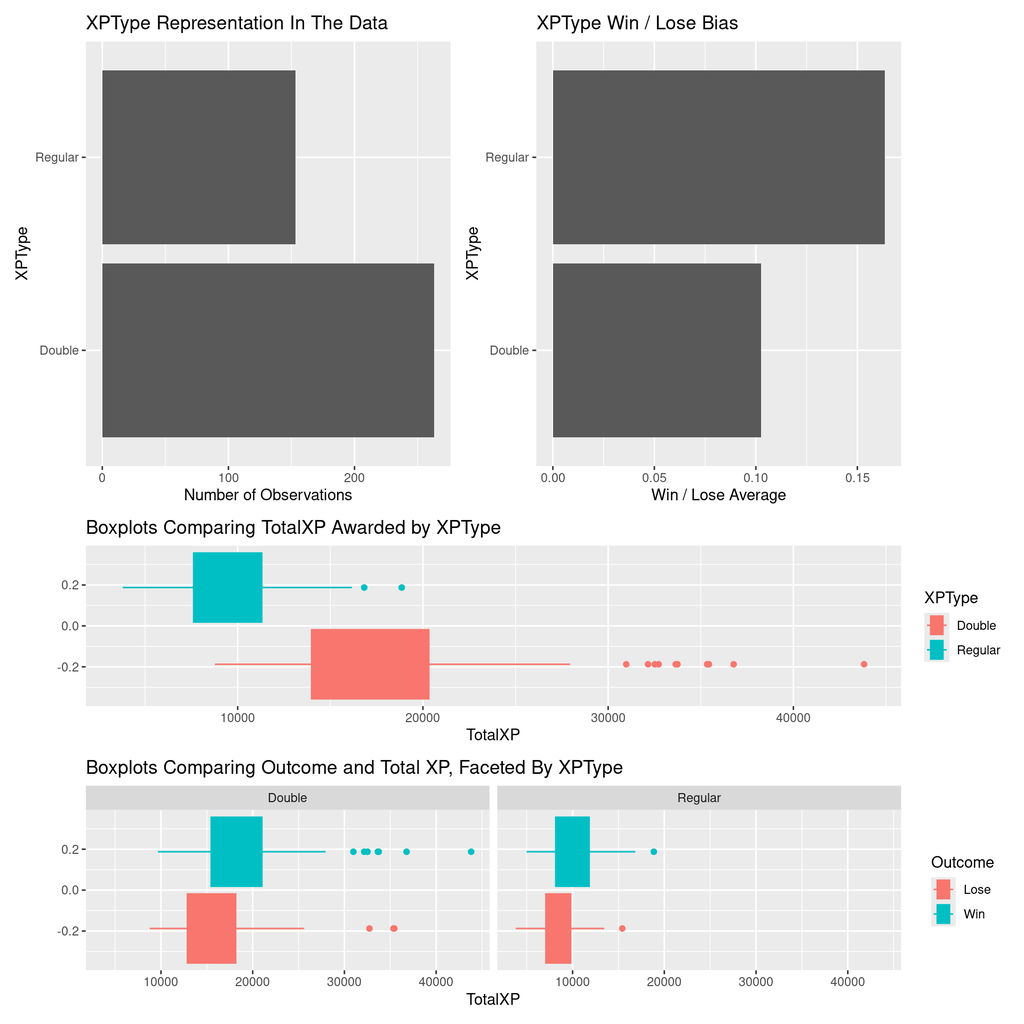

```r
temp_df <- cod_df %>%
  mutate(Outcome = ifelse(Outcome == 1, 1, -1)) %>%
  group_by(XPType) %>%
  summarise(Outcome = mean(Outcome),
            Count = n())

frequency <- ggplot(temp_df, aes(x = XPType, y = Count)) + geom_col() + coord_flip() + labs(x = "XPType", y = "Number of Observations",
                                                                                                         title = "XPType Representation In The Data")
outcome_bias <- ggplot(temp_df, aes(x = XPType, y = Outcome)) + geom_col() + coord_flip() + labs(x = "XPType", y = "Win / Lose Average",
                                                                                                         title = "XPType Win / Lose Bias")


xp1 <- ggplot(cod_df, aes(TotalXP, color = XPType, fill = XPType )) + geom_boxplot()
xp2 <- ggplot(cod_df %>% mutate(Outcome = ifelse(Outcome == 1, "Win", "Lose")), aes(TotalXP, color = Outcome, fill = Outcome )) + geom_boxplot() + facet_wrap(~XPType)
(frequency+outcome_bias) / ((xp1 + labs(title = "Boxplots Comparing TotalXP Awarded by XPType"))/ (xp2 + labs(title = "Boxplots Comparing Outcome and Total XP, Faceted By XPType")))
```

As with the game mode feature, the class imbalance seems to be minimal and there is only a slight bias towards victory, as expected due to victories being more prominent in the data. However, the XPType directly affects the totalXP awarded for the match. The lower boxplots show that there is a slight trend of higher experience payout leading to victory.

It seems that the XPType should remain included since it describes an increase to the totalXP awarded that is not based on player performance.

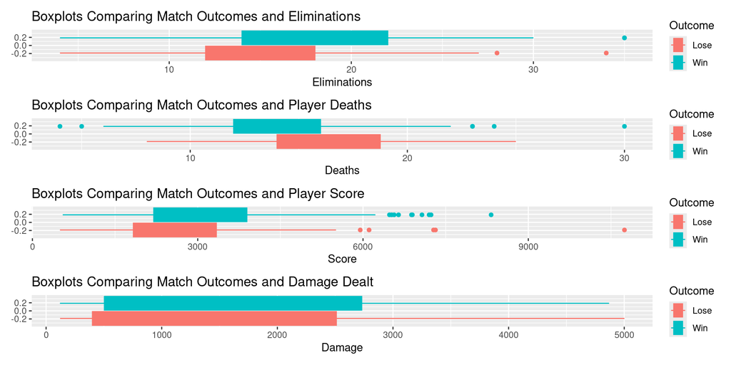

```r
eliminations <-  ggplot(cod_df %>% mutate(Outcome = ifelse(Outcome == 1, "Win", "Lose")), aes(Eliminations, color = Outcome, fill = Outcome )) + geom_boxplot()
deaths <- ggplot(cod_df %>% mutate(Outcome = ifelse(Outcome == 1, "Win", "Lose")), aes(Deaths, color = Outcome, fill = Outcome )) + geom_boxplot()
scores <- ggplot(cod_df %>% mutate(Outcome = ifelse(Outcome == 1, "Win", "Lose")), aes(Score, color = Outcome, fill = Outcome )) + geom_boxplot()
damage <- ggplot(cod_df %>% mutate(Outcome = ifelse(Outcome == 1, "Win", "Lose")), aes(Damage, color = Outcome, fill = Outcome )) + geom_boxplot()

((eliminations + labs(title = "Boxplots Comparing Match Outcomes and Eliminations"))/(deaths + labs(title = "Boxplots Comparing Match Outcomes and Player Deaths"))/(scores + labs(title = "Boxplots Comparing Match Outcomes and Player Score"))/(damage + labs(title = "Boxplots Comparing Match Outcomes and Damage Dealt")))
```

Lastly, the win and loss outcomes seem to vary reasonably based on the game metrics, such as wins being more wins for more eliminations and losses being associated with more deaths.

## Task 2 Classification Models

Before creating any classification models, the data will be split into training and validation sets.

#### Train/Validation Split

```r
cod_df <- cod_df %>%
  mutate(XPType = ifelse(XPType == "Regular", 1, 0)) %>%
  mutate(Mode = ifelse(Mode == "HardCore", 1, 0))
xvars <- names(cod_df %>% select(-Outcome))
cod_df[, xvars] <- scale(x = cod_df[, xvars], center = TRUE, scale = TRUE)
set.seed(123)
trainInd <- sample(1:nrow(cod_df), floor(0.8*nrow(cod_df)))
set.seed(NULL)
Train <- cod_df[trainInd, ]
Validation <- cod_df[-trainInd,]

Xmat <- model.matrix(Outcome ~ ., data = cod_df)[, -1]
yvec <- cod_df$Outcome
XmatTrain <- Xmat[trainInd,]
XmatVal <- Xmat[-trainInd,]
yvecTrain <- yvec[trainInd]
yvecVal <- yvec[-trainInd]
```

The data was split using a random seed of 123 and a 80%/20% split. The resulting training set has 332 observations while the validation set has 84

Additionally, the XPType was encoded such that regular XP matches have a 1 and Double XP matches have a 0. Similarly, the game mode was encoded such that HardCore games have a value of 1 and Core games have a value of 0.

After the encoding, the data was standardized to have a center of 0 and a standard deviation of 1.

*Note:* To prevent researcher influence, the validation set will not be considered until all of the classification models have created using the training data.

#### Logistic Regression

A best subsets approach with backward elimination will be used to perform the logistic regression.

```r
intercept_only <- glm(Outcome ~ 1,
                      family = binomial,
                      data = Train)

full_model <- glm(Outcome ~ .,
                  family = binomial,
                  data = Train)

stats::step(object = full_model,
            scope = list(lower = intercept_only, upper = full_model),
            data = Train,
            direction = "backward")
```

```
## Start:  AIC=384.76
## Outcome ~ Eliminations + Deaths + Score + Damage + TotalXP +
##     XPType + Mode
##
##                Df Deviance    AIC
## - Mode          1   369.06 383.06
## <none>              368.76 384.76
## - Damage        1   371.12 385.12
## - XPType        1   384.90 398.90
## - TotalXP       1   389.87 403.87
## - Eliminations  1   394.66 408.66
## - Score         1   398.90 412.90
## - Deaths        1   403.31 417.31
##
## Step:  AIC=383.06
## Outcome ~ Eliminations + Deaths + Score + Damage + TotalXP +
##     XPType
##
##                Df Deviance    AIC
## <none>              369.06 383.06
## - Damage        1   377.27 389.27
## - XPType        1   385.07 397.07
## - TotalXP       1   390.88 402.88
## - Eliminations  1   398.51 410.51
## - Score         1   401.86 413.86
## - Deaths        1   407.36 419.36
```

```
##
## Call:  glm(formula = Outcome ~ Eliminations + Deaths + Score + Damage +
##     TotalXP + XPType, family = binomial, data = Train)
##
## Coefficients:
##  (Intercept)  Eliminations        Deaths         Score        Damage
##       0.2941        1.5001       -0.8725       -1.4362       -0.4948
##      TotalXP        XPType
##       1.0441        0.7461
##
## Degrees of Freedom: 331 Total (i.e. Null);  325 Residual
## Null Deviance:       457.5
## Residual Deviance: 369.1     AIC: 383.1
```

Based on the Decreasing AIC score, it appears that the best logistic regression model has an AIC of 383.06.

```r
model_logistic <- glm(Outcome ~ Damage + XPType + TotalXP + Eliminations + Score + Deaths, data = Train, family = binomial)
summary(model_logistic)
```

```
##
## Call:
## glm(formula = Outcome ~ Damage + XPType + TotalXP + Eliminations +
##     Score + Deaths, family = binomial, data = Train)
##
## Coefficients:
##              Estimate Std. Error z value Pr(>|z|)
## (Intercept)    0.2941     0.1290   2.279 0.022662 *
## Damage        -0.4948     0.1789  -2.766 0.005673 **
## XPType         0.7461     0.1924   3.878 0.000105 ***
## TotalXP        1.0441     0.2360   4.424 9.71e-06 ***
## Eliminations   1.5001     0.2946   5.092 3.54e-07 ***
## Score         -1.4362     0.2733  -5.254 1.49e-07 ***
## Deaths        -0.8725     0.1538  -5.674 1.39e-08 ***
## ---
## Signif. codes:  0 '***' 0.001 '**' 0.01 '*' 0.05 '.' 0.1 ' ' 1
##
## (Dispersion parameter for binomial family taken to be 1)
##
##     Null deviance: 457.54  on 331  degrees of freedom
## Residual deviance: 369.06  on 325  degrees of freedom
## AIC: 383.06
##
## Number of Fisher Scoring iterations: 4
```

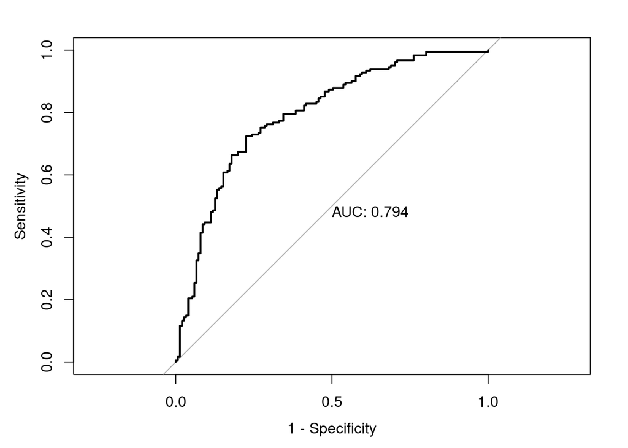

```r
#Metrics for the logistic regression:
predProb <- predict(model_logistic, newdata = Train, type = "response")
rocCurve2 = roc(response = Train$Outcome,
               predictor = predProb,
               plot = TRUE,
               print.auc = TRUE,
               legacy.axes=TRUE)
```

The area under the curve for the logistic regression model against the training data is: 0.794

Next, the classification threshold needs to be chosen for the logistic regression. The method to choose the optimal threshold will be iterating from 1 to 1000 and dividing each ith number by 1000. That resulting number will be the classification threshold. Then the accuracy will be recorded using that temporary threshold.

Since there are not any special concerns with Type I or Type II errors, this approach should be acceptatble in the scope of the classification task.

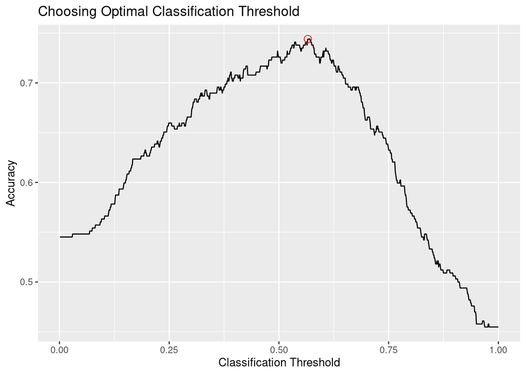

```r
res <- 1000
accVec <- rep(NA, res)
thresholdVec <- rep(NA, res)
for (i in 1:res){
  threshold = i/res
  predOutcome <- ifelse(predProb > threshold, 1, 0)
  accVec[i] <- mean(predOutcome == Train$Outcome)
  thresholdVec[i] <- threshold

}
best_threshold <- which.max(accVec)/res
tempDF <- data.frame(k = thresholdVec, Accuracy = accVec)
ggplot(tempDF, aes(x = k, y = Accuracy)) + geom_line() + geom_point(data = tempDF[which.max(accVec),], color = "red", shape = 1, size = 3) +
  labs(x = "Classification Threshold", y = "Accuracy", title = "Choosing Optimal Classification Threshold")
```

Based on the plot, the best threshold for the logistic regression appears to be 0.566

```r
accuracy_func <- function(Pred, Truth) {
  return(round(mean(Pred == Truth), digits = 3))
}
specificity_func <- function(Pred, Truth) {
  tn <- sum(Pred == 0 & Truth == 0)
  fp <- sum(Pred == 1 & Truth == 0)
  score <- tn/(tn + fp)
  return(round(score, digits =  3))
}
sensitivity_func <- function(Pred, Truth) {
  tp <- sum(Pred == 1 & Truth == 1)
  fn <- sum(Pred == 0 & Truth == 1)
  score <- tp/(tp + fn)
  return(round(score, digits =  3))
}
precision_func <- function(Pred, Truth) {
  tp <- sum(Pred == 1 & Truth == 1)
  fp <- sum(Pred == 1 & Truth == 0)
  score <- tp/(tp + fp)
  return(round(score, digits =  3))
}
predOutcome <- ifelse(predProb > best_threshold, 1, 0)
table(predOutcome, Train$Outcome)
```

```
##
## predOutcome   0   1
##           0 116  50
##           1  35 131
```

The confusion matrix confirms that the model correctly classifies most of the outcomes and that it tends to have slightly more false negatives than false positives.

The other classification metrics against the training set using a classification threshold of 0.566 are:

1. **Accuracy**: 0.744
2. **Specificity**: 0.768
3. **Sensitivity**: 0.724
4. **Precision**: 0.789

#### k-Nearest Neighbors

The k tuning parameter will be chosen by performing 10 cross folds for each k value candidate and averaging the accuracy for each fold. The candidate k values will be explored from $K = 1$ to $K = 100$

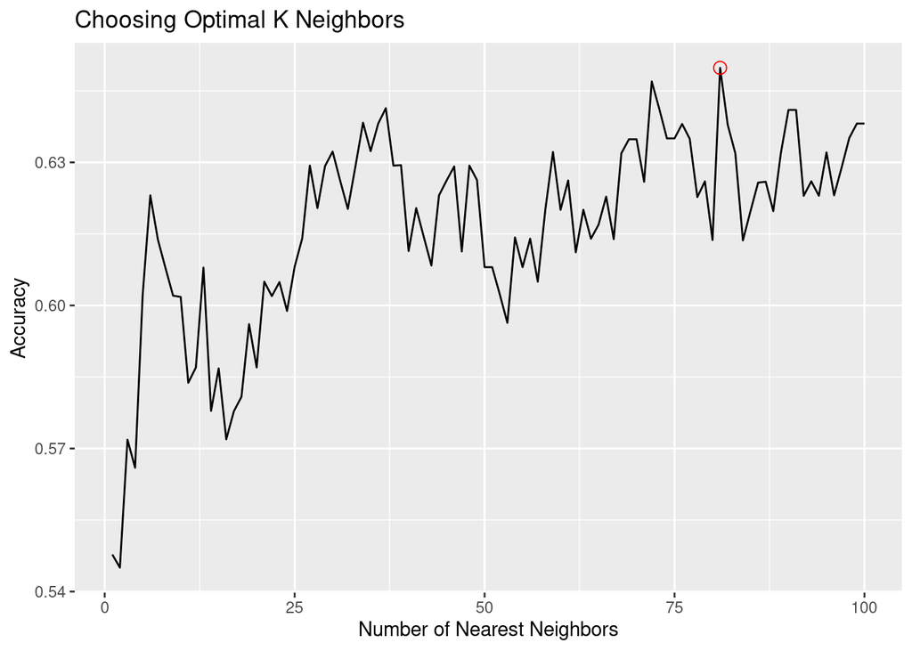

```r
set.seed(123)
num_folds <- 10
xvars <- names(Train %>% select(-Outcome))
folds <- cut(x = 1:nrow(Train), breaks = num_folds, labels = FALSE)


folds <- sample(folds) #randomly permute the fold values

#Initialize
maxK <- 100
accMatrix <- matrix(NA, nrow = num_folds, ncol = maxK)

#Loop for using various values of k
for(i in 1:num_folds){
  #Perform Data Split
  valInd <- which(folds == i)
  validation_temp <- Train[valInd, ]
  train_temp <- Train[-valInd, ]

  for(j in 1:maxK){
    #Build kNN model
    knnResTemp <-
    knn(train = train_temp[ , xvars, drop = FALSE],
        test = validation_temp[ , xvars, drop = FALSE],
        cl = train_temp$Outcome,
        k = j)
    #Add predictions to validation data
    validation_temp <-
      validation_temp %>%
      mutate(predOutcome = knnResTemp)

    #Store result
    accMatrix[i,j] <- mean(validation_temp$Outcome == validation_temp$predOutcome)
    }
}
#For each value of k, average accuracy values across the 10 folds
accMeans <- apply(accMatrix, 2, mean)

#Create a temporary data frame for plotting
tempDF <- data.frame(k = 1:maxK, Accuracy = accMeans)

#Create a plot showing accuracy as a function of k
ggplot(data = tempDF,
       mapping = aes(x = k, y = Accuracy)) +
  geom_line() +
  labs(x = "Number of Nearest Neighbors",
       y = "Accuracy",
       title = "Choosing Optimal K Neighbors") +
  geom_point(data = tempDF[which.max(accMeans), ],
             color = "red", shape = 1, size =3)
```

```r
accMeans_bak <- accMeans
best_k <- as.numeric(which.max(accMeans))
accMeans[best_k] <- 0
second_best_k <- as.numeric(which.max(accMeans))
accMeans[which.max(accMeans)] <- 0
third_best_k <- as.numeric(which.max(accMeans))
```

Based on the plot, the top 3 best K values are:

1. 81 with a training accuracy of 0.65
2. 72 with a training accuracy of 0.647
3. 37 with a training accuracy of 0.641

Given that the third best k value uses nearly half the neighbors and achieves an accuracy score close to the using 81 neighbors, 37 might be the best k parameter for hopes of minimizing over fitting.

```r
set.seed(123)
trainInd <- sample(1:nrow(Train), floor(0.7*nrow(Train)))
train_temp <- Train[trainInd,]
validation_temp <- Train[-trainInd, ]

knnResTemp <-
    knn(train = train_temp[ , xvars, drop = FALSE],
        test = validation_temp[ , xvars, drop = FALSE],
        cl = train_temp$Outcome,
        k = best_k)

predOutcome1 <- ifelse(knnResTemp == 1, 1, 0)
table(predOutcome1, validation_temp$Outcome)
```

```
##
## predOutcome1  0  1
##            0 16 17
##            1 28 39
```

The confusion matrix confirms that the model correctly classifies most of the outcomes and that it tends to have slightly more false positives than false negatives

The other classification metrics against the training set are:

```r
knnResTemp <-
    knn(train = train_temp[ , xvars, drop = FALSE],
        test = validation_temp[ , xvars, drop = FALSE],
        cl = train_temp$Outcome,
        k = second_best_k)

predOutcome2 <- ifelse(knnResTemp == 1, 1, 0)

knnResTemp <-
    knn(train = train_temp[ , xvars, drop = FALSE],
        test = validation_temp[ , xvars, drop = FALSE],
        cl = train_temp$Outcome,
        k = third_best_k)

predOutcome3 <- ifelse(knnResTemp == 1, 1, 0)


performance_df <- data.frame(Name = "KNN (K=81)",
                             Accuracy = accuracy_func(predOutcome1, validation_temp$Outcome),
                             Specificity = specificity_func(predOutcome1, validation_temp$Outcome),
                             Sensitivity = sensitivity_func(predOutcome1, validation_temp$Outcome),
                             Precision = precision_func(predOutcome1, validation_temp$Outcome))
performance_df <- rbind(performance_df,
                        data.frame(Name = "KNN (K=72)",
                             Accuracy = accuracy_func(predOutcome2, validation_temp$Outcome),
                             Specificity = specificity_func(predOutcome2, validation_temp$Outcome),
                             Sensitivity = sensitivity_func(predOutcome2, validation_temp$Outcome),
                             Precision = precision_func(predOutcome2, validation_temp$Outcome)))

performance_df <- rbind(performance_df,
                        data.frame(Name = "KNN (K=37)",
                             Accuracy = accuracy_func(predOutcome3, validation_temp$Outcome),
                             Specificity = specificity_func(predOutcome3, validation_temp$Outcome),
                             Sensitivity = sensitivity_func(predOutcome3, validation_temp$Outcome),
                             Precision = precision_func(predOutcome3, validation_temp$Outcome)))
reactable(performance_df)
```

| Name | Accuracy | Specificity | Sensitivity | Precision |
| --- | --- | --- | --- | --- |
| KNN (K=81) | 0.55 | 0.364 | 0.696 | 0.582 |
| KNN (K=72) | 0.51 | 0.386 | 0.607 | 0.557 |
| KNN (K=37) | 0.51 | 0.386 | 0.607 | 0.557 |

The model with a k value of 81 generally has the better scores, but it might perform worse against the validation data due to having so many neighbors and the risk of over fitting.

#### Classification Tree

The third model for the classification task will be a classification tree. The first tree will be created using all of the features with a complexity parameter of 0.001 and will use 10 cross folds.

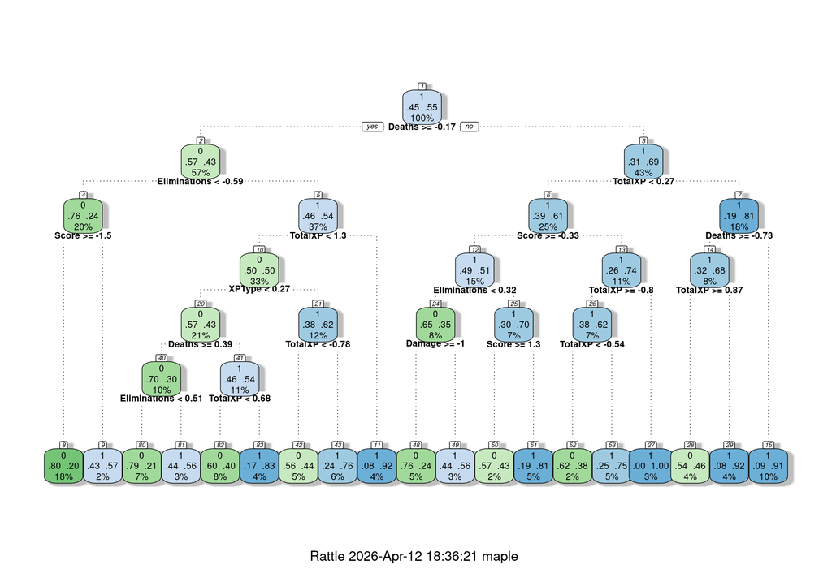

```r
set.seed(123)
fullTree <- rpart(Outcome ~ . , data = Train, method = "class", cp = 0.001, xval = 10)
cpRow <- which.min(fullTree$cptable[ , "xerror"])

target <- fullTree$cptable[ , "xerror"][cpRow] +fullTree$cptable[ , "xstd"][cpRow]

cpRow1se <- which(fullTree$cptable[ , "xerror"] < target)[1]
cpChoice1se <- fullTree$cptable[ , "CP"][cpRow1se]
fancyRpartPlot(fullTree, cex=0.65)
```

The resulting tree has 19 terminal nodes, each with a small portion of the training data terminating at those nodes, so this tree has severe risk of over fitting.

```r
printout <- summary(fullTree)
```

```r
printout$variable.importance
```

```
##      TotalXP Eliminations       Deaths        Score       Damage       XPType
##    23.330330    18.273785    17.492621    17.329518    14.357144     4.233392
##         Mode
##     2.581682
```

```r
fullTree$cptable
```

```
##            CP nsplit rel error    xerror       xstd
## 1 0.165562914      0 1.0000000 1.0000000 0.06008717
## 2 0.066225166      1 0.8344371 1.0000000 0.06008717
## 3 0.033112583      2 0.7682119 0.9801325 0.05997825
## 4 0.026490066      4 0.7019868 0.9470199 0.05975207
## 5 0.017660044      6 0.6490066 0.9470199 0.05975207
## 6 0.013245033      9 0.5960265 0.9470199 0.05975207
## 7 0.006622517     10 0.5827815 0.9668874 0.05989450
## 8 0.003311258     16 0.5430464 1.0198675 0.06017615
## 9 0.001000000     18 0.5364238 1.0198675 0.06017615
```

Using the cptable and the 1 standard error rule, the optimal cp value is 0.166. Pruning the tree with this tuning parameter yields the following tree

```r
prunedTree <- prune(fullTree, cp=cpRow1se)
summary(prunedTree)
```

```
## Call:
## rpart(formula = Outcome ~ ., data = Train, method = "class",
##     cp = 0.001, xval = 10)
##   n= 332
##
##   CP nsplit rel error xerror       xstd
## 1  1      0         1      1 0.06008717
##
## Node number 1: 332 observations
##   predicted class=1  expected loss=0.4548193  P(node) =1
##     class counts:   151   181
##    probabilities: 0.455 0.545
```

The resulting pruned tree is a tree with a single terminal node. The pruned tree appears to be too pruned while the full tree seems likely to over fit.

Therefore a second full tree will be created using the first four most significant features:

1. TotalXP
2. Eliminations
3. Deaths
4. Score

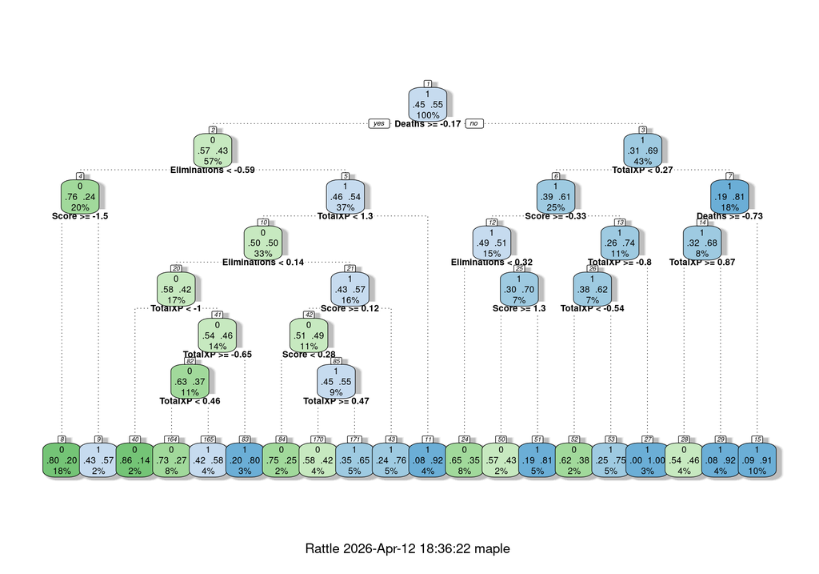

```r
set.seed(123)
fullTree2 <- rpart(Outcome ~ TotalXP + Eliminations + Deaths + Score , data = Train, method = "class", cp = 0.001, xval = 10)
cpRow <- which.min(fullTree2$cptable[ , "xerror"])

target <- fullTree2$cptable[ , "xerror"][cpRow] +fullTree2$cptable[ , "xstd"][cpRow]

cpRow1se <- which(fullTree2$cptable[ , "xerror"] < target)[1]
cpChoice1se <- fullTree2$cptable[ , "CP"][cpRow1se]
fancyRpartPlot(fullTree2, cex=0.65)
```

```r
fullTree2$cptable
```

```
##            CP nsplit rel error    xerror       xstd
## 1 0.165562914      0 1.0000000 1.0000000 0.06008717
## 2 0.066225166      1 0.8344371 1.0000000 0.06008717
## 3 0.029801325      2 0.7682119 0.9735099 0.05993749
## 4 0.019867550      4 0.7086093 0.8940397 0.05927260
## 5 0.017660044      6 0.6688742 0.8874172 0.05920236
## 6 0.013245033      9 0.6158940 0.8543046 0.05881619
## 7 0.006622517     13 0.5629139 0.8807947 0.05912979
## 8 0.003311258     17 0.5364238 0.9668874 0.05989450
## 9 0.001000000     19 0.5298013 0.9867550 0.06001678
```

Using the cptable of the second full tree and the 1 standard error rule, the optimal cp value is 0.02. Pruning the second full tree with this tuning parameter yields the following:

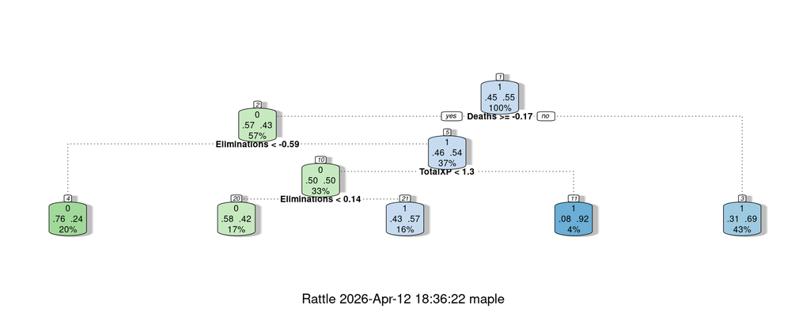

```r
prunedTree2 <- prune(fullTree2, cp=cpChoice1se)
fancyRpartPlot(prunedTree2, cex=0.65)
```

This second pruned tree is much more reasonable than the first pruned tree created previously. It seems to capture the essential of the second full tree while having only 5 terminal nodes. This second pruned treee should be much less prone to overfitting and might perform the best of the trees against the validation set.

```r
fullTree_pred <- predict(fullTree, newdata = Train, type = "class")
prunedTree_pred <- predict(prunedTree, newdata = Train, type = "class")
fullTree2_pred <- predict(fullTree2, newdata = Train, type = "class")
prunedTree2_pred <- predict(prunedTree2, newdata = Train, type = "class")

performance_df <- data.frame(Name = "Full Tree",
                             Accuracy = accuracy_func(fullTree_pred, Train$Outcome),
                             Specificity = specificity_func(fullTree_pred, Train$Outcome),
                             Sensitivity = sensitivity_func(fullTree_pred, Train$Outcome),
                             Precision = precision_func(fullTree_pred, Train$Outcome))
performance_df <- rbind(performance_df,
                        data.frame(Name = "Pruned Tree",
                             Accuracy = accuracy_func(prunedTree_pred, Train$Outcome),
                             Specificity = specificity_func(prunedTree_pred, Train$Outcome),
                             Sensitivity = sensitivity_func(prunedTree_pred, Train$Outcome),
                             Precision = precision_func(prunedTree_pred, Train$Outcome)))

performance_df <- rbind(performance_df,
                        data.frame(Name = "Full Tree 2",
                             Accuracy = accuracy_func(fullTree2_pred, Train$Outcome),
                             Specificity = specificity_func(fullTree2_pred, Train$Outcome),
                             Sensitivity = sensitivity_func(fullTree2_pred, Train$Outcome),
                             Precision = precision_func(fullTree2_pred, Train$Outcome)))

performance_df <- rbind(performance_df,
                        data.frame(Name = "Pruned Tree 2",
                             Accuracy = accuracy_func(prunedTree2_pred, Train$Outcome),
                             Specificity = specificity_func(prunedTree2_pred, Train$Outcome),
                             Sensitivity = sensitivity_func(prunedTree2_pred, Train$Outcome),
                             Precision = precision_func(prunedTree2_pred, Train$Outcome)))

reactable(performance_df)
```

| Name | Accuracy | Specificity | Sensitivity | Precision |
| --- | --- | --- | --- | --- |
| Full Tree | 0.756 | 0.801 | 0.718 | 0.812 |
| Pruned Tree | 0.545 | 0 | 1 | 0.545 |
| Full Tree 2 | 0.759 | 0.788 | 0.735 | 0.806 |
| Pruned Tree 2 | 0.678 | 0.55 | 0.785 | 0.676 |

The second full tree has the best accuracy out of all of the trees created and the second pruned tree performs better than the first pruned tree.

#### Comparison of Models

Next the classification models will be evaluated against the validation set for the first time to assess how they perform against unseen data.

```r
set.seed(123)
fullTree_pred <- predict(fullTree, newdata = Validation, type = "class")
prunedTree_pred <- predict(prunedTree, newdata = Validation, type = "class")
fullTree2_pred <- predict(fullTree2, newdata = Validation, type = "class")
prunedTree2_pred <- predict(prunedTree2, newdata = Validation, type = "class")

performance_df <- data.frame(Name = "Full Tree",
                             Accuracy = accuracy_func(fullTree_pred, Validation$Outcome),
                             Specificity = specificity_func(fullTree_pred, Validation$Outcome),
                             Sensitivity = sensitivity_func(fullTree_pred, Validation$Outcome),
                             Precision = precision_func(fullTree_pred, Validation$Outcome))
performance_df <- rbind(performance_df,
                        data.frame(Name = "Pruned Tree",
                             Accuracy = accuracy_func(prunedTree_pred, Validation$Outcome),
                             Specificity = specificity_func(prunedTree_pred, Validation$Outcome),
                             Sensitivity = sensitivity_func(prunedTree_pred, Validation$Outcome),
                             Precision = precision_func(prunedTree_pred, Validation$Outcome)))

performance_df <- rbind(performance_df,
                        data.frame(Name = "Full Tree 2",
                             Accuracy = accuracy_func(fullTree2_pred, Validation$Outcome),
                             Specificity = specificity_func(fullTree2_pred, Validation$Outcome),
                             Sensitivity = sensitivity_func(fullTree2_pred, Validation$Outcome),
                             Precision = precision_func(fullTree2_pred, Validation$Outcome)))

performance_df <- rbind(performance_df,
                        data.frame(Name = "Pruned Tree 2",
                             Accuracy = accuracy_func(prunedTree2_pred, Validation$Outcome),
                             Specificity = specificity_func(prunedTree2_pred, Validation$Outcome),
                             Sensitivity = sensitivity_func(prunedTree2_pred, Validation$Outcome),
                             Precision = precision_func(prunedTree2_pred, Validation$Outcome)))

knnResTemp <-
    knn(train = Train[ , xvars, drop = FALSE],
        test = Validation[ , xvars, drop = FALSE],
        cl = Train$Outcome,
        k = best_k)

predOutcome1 <- ifelse(knnResTemp == 1, 1, 0)

knnResTemp <-
    knn(train = Train[ , xvars, drop = FALSE],
        test = Validation[ , xvars, drop = FALSE],
        cl = Train$Outcome,
        k = second_best_k)

predOutcome2 <- ifelse(knnResTemp == 1, 1, 0)

knnResTemp <-
    knn(train = Train[ , xvars, drop = FALSE],
        test = Validation[ , xvars, drop = FALSE],
        cl = Train$Outcome,
        k = third_best_k)

predOutcome3 <- ifelse(knnResTemp == 1, 1, 0)


performance_df <- rbind(performance_df,
                        data.frame(Name = "KNN (K=81)",
                             Accuracy = accuracy_func(predOutcome1, Validation$Outcome),
                             Specificity = specificity_func(predOutcome1, Validation$Outcome),
                             Sensitivity = sensitivity_func(predOutcome1, Validation$Outcome),
                             Precision = precision_func(predOutcome1, Validation$Outcome)))
performance_df <- rbind(performance_df,
                        data.frame(Name = "KNN (K=72)",
                             Accuracy = accuracy_func(predOutcome2, Validation$Outcome),
                             Specificity = specificity_func(predOutcome2, Validation$Outcome),
                             Sensitivity = sensitivity_func(predOutcome2, Validation$Outcome),
                             Precision = precision_func(predOutcome2, Validation$Outcome)))

performance_df <- rbind(performance_df,
                        data.frame(Name = "KNN (K=37)",
                             Accuracy = accuracy_func(predOutcome3, Validation$Outcome),
                             Specificity = specificity_func(predOutcome3, Validation$Outcome),
                             Sensitivity = sensitivity_func(predOutcome3, Validation$Outcome),
                             Precision = precision_func(predOutcome3, Validation$Outcome)))

predProb <- predict(model_logistic, newdata = Validation, type = "response")
predOutcome <- ifelse(predProb > best_threshold, 1, 0)

performance_df <- rbind(performance_df,
                        data.frame(Name = "Logistic Regression (Threshold= 0.566)",
                             Accuracy = accuracy_func(predOutcome, Validation$Outcome),
                             Specificity = specificity_func(predOutcome, Validation$Outcome),
                             Sensitivity = sensitivity_func(predOutcome, Validation$Outcome),
                             Precision = precision_func(predOutcome, Validation$Outcome)))


reactable(performance_df)
```

| Name | Accuracy | Specificity | Sensitivity | Precision |
| --- | --- | --- | --- | --- |
| Full Tree | 0.595 | 0.613 | 0.585 | 0.721 |
| Pruned Tree | 0.631 | 0 | 1 | 0.631 |
| Full Tree 2 | 0.571 | 0.581 | 0.566 | 0.698 |
| Pruned Tree 2 | 0.714 | 0.645 | 0.755 | 0.784 |
| KNN (K=81) | 0.75 | 0.645 | 0.811 | 0.796 |
| KNN (K=72) | 0.762 | 0.71 | 0.792 | 0.824 |
| KNN (K=37) | 0.726 | 0.581 | 0.811 | 0.768 |
| Logistic Regression (Threshold= 0.566) | 0.702 | 0.645 | 0.736 | 0.78 |

The classification trees performed fairly well against the validation data, with the second pruned tree scoring the highest accuracy, even surpassing the logistic regression model.

The K-Nearest Neighbors models generally performed the better than the other families of classifiers, with the model using a k value of 72 generalizing the best to the validation set.

The final confusion matrix is:

```r
table(predOutcome2, Validation$Outcome)
```

```
##
## predOutcome2  0  1
##            0 22 11
##            1  9 42
```

The best KNN model performs well, but tends to have more false negatives than false positives.

## Task 3 Extending an Unit 2 Topic

To perform logistic regression using lasso and the glmnet packet, the family parameter needs to be set to “binomial” (Martin, 2025).

```r
lassoCV <- cv.glmnet(x = XmatTrain, y = yvecTrain,
                    family = "binomial",
                    alpha = 1,
                    lambda = NULL,
                    standardize = TRUE,
                    nfolds = 10)
coefLam1se <- predict(lassoCV, s = lassoCV$lambda.1se, type = "coefficients")
tempdf <- data.frame(Feature = row.names(coefLam1se), lam1se = as.numeric(coefLam1se))
reactable(tempdf, searchable = FALSE, compact = TRUE, striped = TRUE, defaultPageSize = 13, showPageSizeOptions = FALSE)
```

| Feature | lam1se |
| --- | --- |
| (Intercept) | 0.223333684119365 |
| Eliminations | 0.670849870417935 |
| Deaths | -0.579674511678093 |
| Score | -0.548360162072016 |
| Damage | -0.100213896876712 |
| TotalXP | 0.51075053854775 |
| XPType | 0.374957143286144 |
| Mode | 0 |

Using the 1 standard error rule, the lambda turning parameter is 0.0164769, the logistic lasso model drives the Mode coefficient to zero, effectively removing it.

Now, to get the win or loss predictions using the model, the type parameter in the predict function needs to be set to response (Martin, 2025).

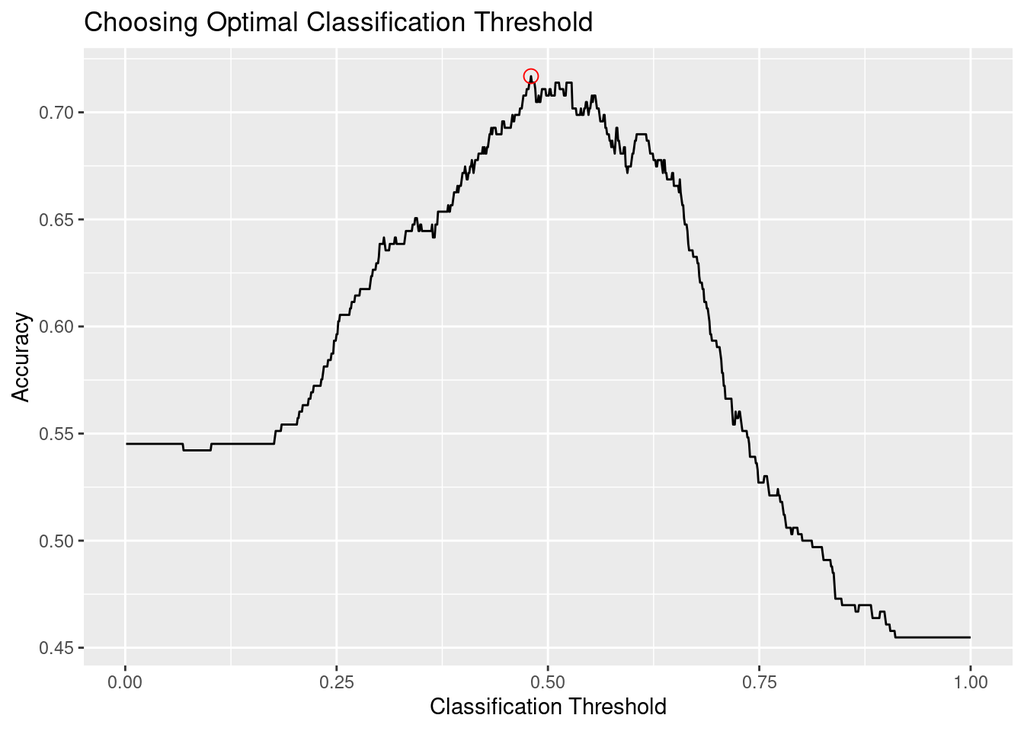

```r
predProb <- predict(lassoCV, s = lassoCV$lambda.1se, newx = XmatTrain, type = 'response')
res <- 1000
accVec <- rep(NA, res)
thresholdVec <- rep(NA, res)
for (i in 1:res){
  threshold = i/res
  predOutcome <- ifelse(predProb > threshold, 1, 0)
  accVec[i] <- mean(predOutcome == yvecTrain)
  thresholdVec[i] <- threshold

}
predOutcome <- ifelse(predProb > threshold, 1, 0)

best_threshold_lasso <- which.max(accVec)/res
tempDF <- data.frame(k = thresholdVec, Accuracy = accVec)
ggplot(tempDF, aes(x = k, y = Accuracy)) + geom_line() + geom_point(data = tempDF[which.max(accVec),], color = "red", shape = 1, size = 3) +
  labs(x = "Classification Threshold", y = "Accuracy", title = "Choosing Optimal Classification Threshold")
```

The optimal threshold for the logistic lasso model is 0.48

```r
predOutcome <- ifelse(predProb > best_threshold_lasso, 1, 0)
table(predOutcome, yvecTrain)
```

```
##            yvecTrain
## predOutcome   0   1
##           0  86  29
##           1  65 152
```

The confusion matrix shows that the logistic lasso model tends to have more false positives than false negatives. The other relevant metrics against the training set are:

1. **Accuracy**: 0.717
2. **Specificity**: 0.57
3. **Sensitivity**: 0.84
4. **Precision**: 0.7

```r
predOutcome <- ifelse(predProb > best_threshold_lasso, 1, 0)
performance_df <- data.frame(Name = "Logistic Lasso (1se=0.165, threshold=0.48",
                             Accuracy = accuracy_func(predOutcome, yvecVal),
                             Specificity = specificity_func(predOutcome, yvecVal),
                             Sensitivity = sensitivity_func(predOutcome, yvecVal),
                             Precision = precision_func(predOutcome, yvecVal))

knnResTemp <- knn(train = Train[ , xvars, drop = FALSE],
        test = Validation[ , xvars, drop = FALSE],
        cl = Train$Outcome,
        k = second_best_k)
performance_df <- rbind(performance_df,
                        data.frame(Name = "KNN (K=72)",
                             Accuracy = accuracy_func(predOutcome2, Validation$Outcome),
                             Specificity = specificity_func(predOutcome2, Validation$Outcome),
                             Sensitivity = sensitivity_func(predOutcome2, Validation$Outcome),
                             Precision = precision_func(predOutcome2, Validation$Outcome)))
reactable(performance_df)
```

| Name | Accuracy | Specificity | Sensitivity | Precision |
| --- | --- | --- | --- | --- |
| Logistic Lasso (1se=0.165, threshold=0.48 | 0.545 | 0.355 | 0.659 | 0.631 |
| KNN (K=72) | 0.762 | 0.71 | 0.792 | 0.824 |

The logistic lasso model performed worse against the validation set compared to the training set, which suggests a problem with over fitting. Therefore, the best model for predicting player victory or defeat is the K-nearest neighbors model with an accuracy of 76.2%

## References

Martin, J. (2025). *“LASSO for Logistic Regression”*. Retrieved From: https://rpubs.com/jmartin/1355833